# Analysis of ACLED data in Africa

Jean-Baptiste Guiffard

2024-10-23

## ACLED

The Armed Conflict Location & Event Data Project (ACLED) is an extensive, geolocated database documenting political violence and protests globally, including regions like Africa, the Middle East, Latin America, the Caribbean, and various parts of Asia, Europe, and the United States. ACLED records event details such as dates, involved parties, casualties, and event types.

The dataset is available for free on the ACLED website, and it is updated on a weekly basis. The data is collected from a variety of sources, including news reports, humanitarian agencies, and local observers. The data is then reviewed by a team of researchers to ensure accuracy and consistency.

## Data download

```r
df_ACLED <- merge(read.csv2('C:/Users/Giffarrd/OneDrive/THESE/CHAP_1_THESIS/MAIN/DATA/ACLED/Africa_1997-2024_Oct18.csv', sep=","),
                  read.csv2('DATA/Country_Alpha-3_Codes.csv', sep=","),
                  by="country",
                  all.x=TRUE)
str(df_ACLED)
```

```
## 'data.frame':    390347 obs. of  32 variables:
##  $ country           : chr  "Algeria" "Algeria" "Algeria" "Algeria" ...
##  $ event_id_cnty     : chr  "ALG4768" "ALG8006" "ALG6705" "ALG8419" ...
##  $ event_date        : chr  "2017-08-02" "2020-01-10" "2019-06-21" "2020-03-08" ...
##  $ year              : int  2017 2020 2019 2020 2020 2013 2020 2021 2019 2019 ...
##  $ time_precision    : int  1 1 1 1 1 2 1 1 1 1 ...
##  $ disorder_type     : chr  "Demonstrations" "Demonstrations" "Demonstrations" "Demonstrations" ...
##  $ event_type        : chr  "Protests" "Protests" "Protests" "Protests" ...
##  $ sub_event_type    : chr  "Peaceful protest" "Peaceful protest" "Peaceful protest" "Peaceful protest" ...
##  $ actor1            : chr  "Protesters (Algeria)" "Protesters (Algeria)" "Protesters (Algeria)" "Protesters (Algeria)" ...
##  $ assoc_actor_1     : chr  "" "" "" "Women (Algeria)" ...
##  $ inter1            : chr  "Protesters" "Protesters" "Protesters" "Protesters" ...
##  $ actor2            : chr  "" "" "" "" ...
##  $ assoc_actor_2     : chr  "" "" "" "" ...
##  $ inter2            : chr  "" "" "" "" ...
```

[output cut: 18 more lines]

## First stats

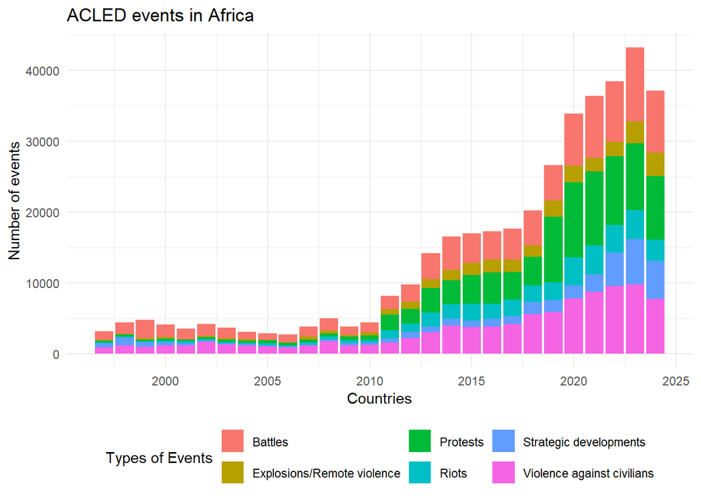

```r
df_ACLED |>
  group_by(year, event_type) |>
  summarise(n=n(), .groups = "drop") |>
  ggplot() +
  geom_bar(aes(x = year, y = n, fill = event_type), stat = "identity") +
  theme_minimal() +
  labs(title = "ACLED events in Africa", x = "Countries", y = "Number of events", fill = "Types of Events") +
  theme(legend.title = element_text(), legend.position = "bottom")
```

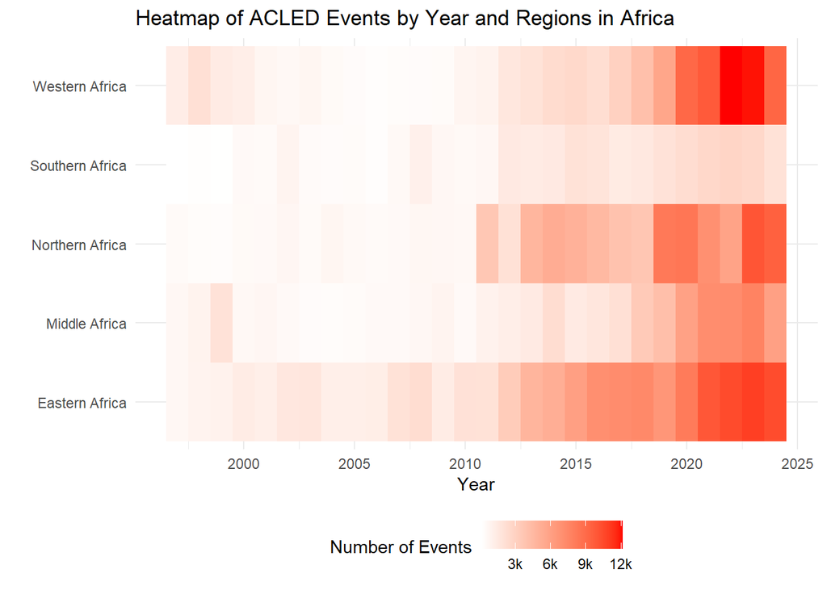

```r
df_ACLED |>
  group_by(year, region) |>
  summarise(n = n(), .groups = "drop") |>
  ggplot(aes(x = year, y = region, fill = n)) +
  geom_tile() +
  scale_fill_gradient(low = "white", high = "red",
                      labels = label_number(scale = 1/1000, suffix = "k"))+
  theme_minimal() +
  labs(title = "Heatmap of ACLED Events by Year and Regions in Africa",
       x = "Year",
       y = "",
       fill = "Number of Events") +
  theme(legend.position = "bottom")
```